# Making data tables in presentations

Bhaskar Kamble

9 Juni 2019

## Purpose

It is often necessary in presentations to present certain data in the form of tables. These tables often need to be formatted in certain ways, such as the correct alignment of text, suitable widths for the columns, merging certain rows or columns, highlighting certain cells and so on. For this, the `grid`and `gridExtra` packages are used. Here I want to describe possible ways to use these packages to get correctly formatted tables, and also some problems I ran into for which I don’t have a solution yet.

```r
library(grid)
library(gridExtra)
library(gtable)
tabla_fin <- rbind(
c("","2015\nabril","2016\nabril","2017\nmarzo","2017\nabril"),
c("Pedidos",-23.3,-13.8,-26,-39),
c("Existencias",7.6,1.2,5.3,10.5),
c("Expectativas",30.7,32.7,28.7,24),
c("ICI",-0.1,5.9,-0.9,-8.5),
c("ICI Desest*",0.4,5.7,-3.2,-6.9))
colnames(tabla_fin) <- tabla_fin[1,]
tabla_fin <- tabla_fin[-1,]
rownames(tabla_fin) <- tabla_fin[,1]
tabla_fin <- tabla_fin[,-1]
print(tabla_fin)
```

```
##              2015\nabril 2016\nabril 2017\nmarzo 2017\nabril
## Pedidos      "-23.3"     "-13.8"     "-26"       "-39"
## Existencias  "7.6"       "1.2"       "5.3"       "10.5"
## Expectativas "30.7"      "32.7"      "28.7"      "24"
## ICI          "-0.1"      "5.9"       "-0.9"      "-8.5"
## ICI Desest*  "0.4"       "5.7"       "-3.2"      "-6.9"
```

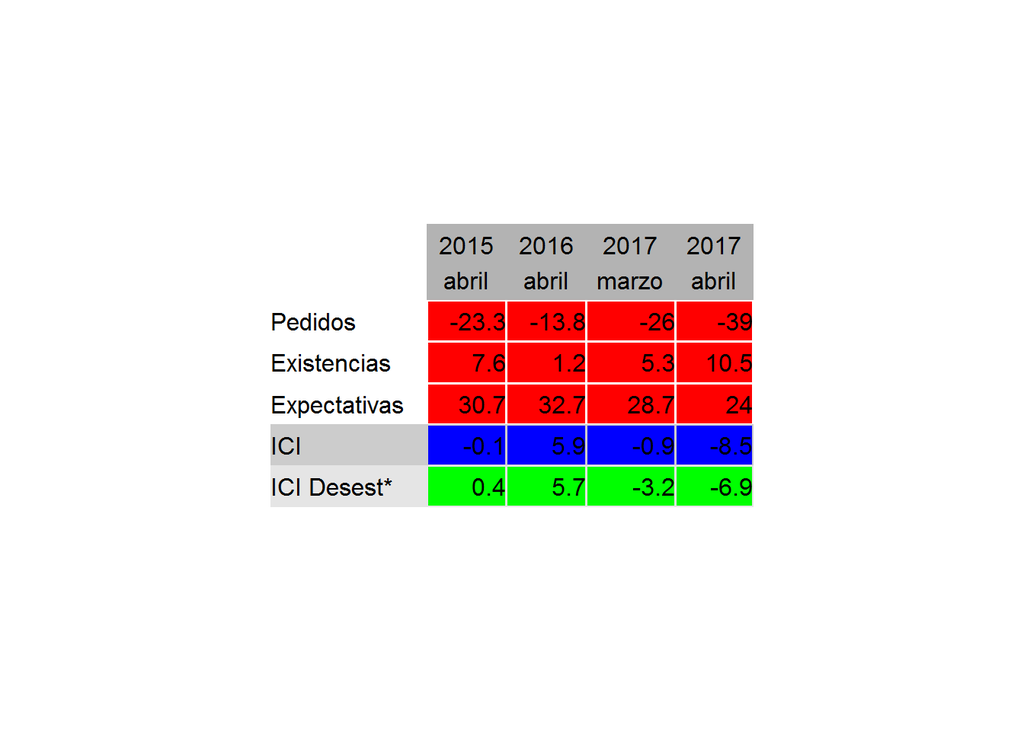

```r
t1 <- ttheme_default(
        core=list(
         fg_params=list(fontface=rep("plain", 6), fontfamily="Calibri",
                      x=1.0, hjust=1.0),
         bg_params = list(
                     fill=c(rep("red",3),"blue","green"),
                     col=c("white","white","white","grey80","grey90"),
                     alpha = rep(1,5))
        ),
        rowhead=list(
         fg_params=list(x=0, hjust=0, fontface="plain", fontfamily="Calibri"),
         bg_params = list(
                     fill=c("white",rep("white",3),"grey80","grey90"),
                     col=c("white","white","white","white","grey80","grey90"),
                     alpha = rep(1,5))
        ),
        colhead=list(
         fg_params=list(fontface="plain",fontfamily="Calibri"),
         bg_params = list(
                     fill="grey70",
                     col="grey70",
                     alpha = rep(1,5))
        )
)
t  <- tableGrob(tabla_fin, theme=t1)
grid.newpage()
grid.draw(t)
```

```r
a <- gtable(unit(1:3, c("cm")), unit(5, "cm"))
a
```

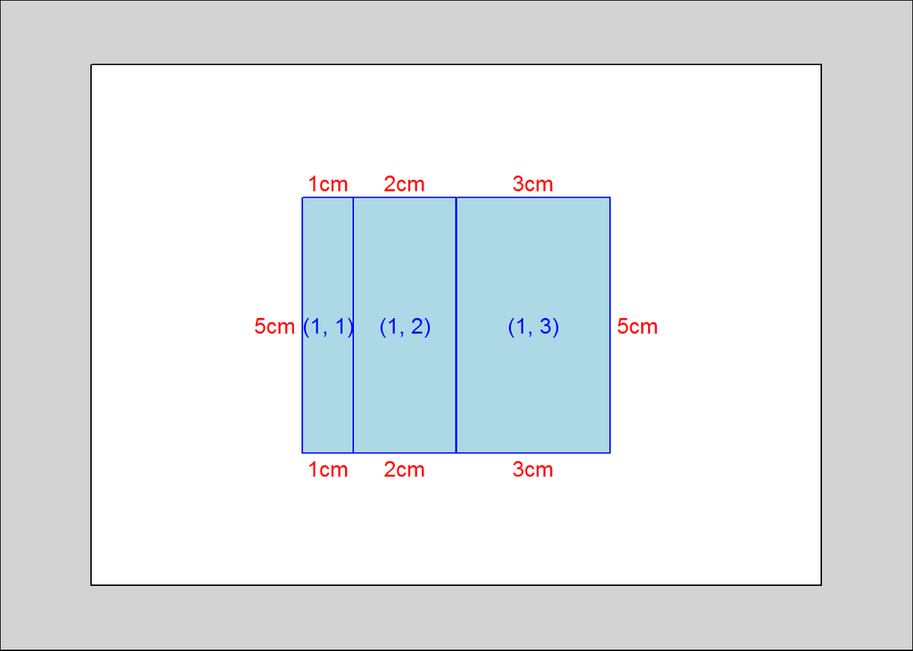

```r
gtable_show_layout(a)
```

```r
# Add a grob:
rect <- rectGrob(gp = gpar(fill = "black"))
a <- gtable_add_grob(a, rect, 1, 1)
a
```

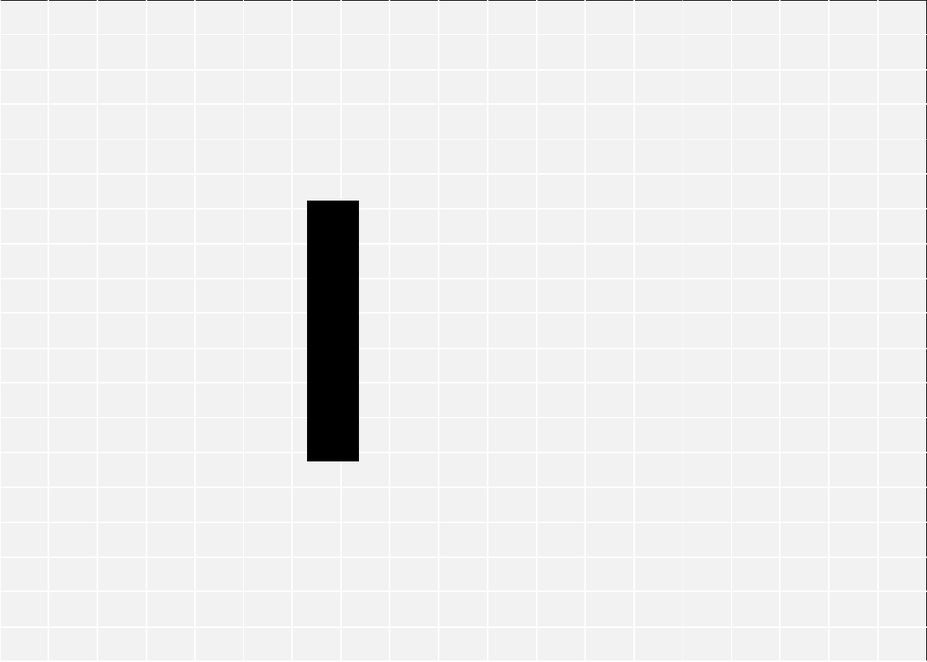

```r
plot(a)
```

```r
library(ggplot2)
p1 <- qplot(mpg, wt, data = mtcars, colour = cyl)
p2 <- qplot(mpg, data = mtcars) + ggtitle("title")
p3 <- qplot(mpg, data = mtcars, geom = "dotplot")
p4 <-
  p1 + facet_wrap( ~ carb, nrow = 1) + theme(legend.position = "none") +
  ggtitle("facetted plot")
```

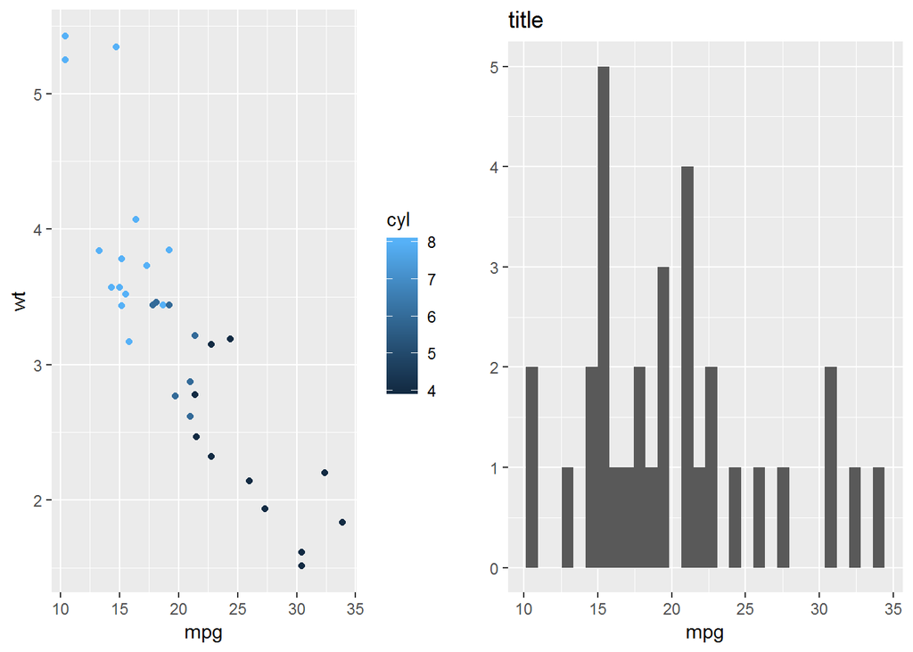

```r
grid.arrange(p1, p2, nrow = 1)
```

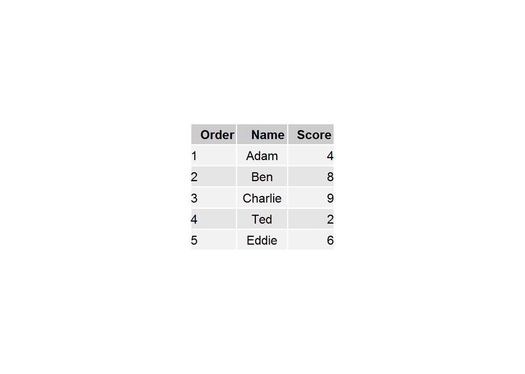

```r
#https://stackoverflow.com/questions/36454028/how-do-i-customize-particular-columns-for-a-tablegrob-in-r
library(grid)
library(gridExtra)

df <- data.frame(Order = c(1:5),
                 Name = c("Adam", "Ben", "Charlie" , "Ted", "Eddie"),
                 Score = c(4, 8, 9 , 2 , 6))

#hj <- matrix(c(0, 0.5, 1), ncol=3, nrow=nrow(df), byrow=TRUE)
#x <- matrix(c(0, 0.5, 1), ncol=3, nrow=nrow(df), byrow=TRUE)

hj <- rep(c(0,0.5,1),each=5)
x <- rep(c(0,0.5,1),each=5)

tt1 <- ttheme_default(core=list(fg_params=list(hjust = hj,
                                               x = x)),
                      colhead=list(fg_params=list(hjust=1, x=0.95)))


dfGrob <- tableGrob(df, rows = NULL, theme = tt1)
grid.newpage()
grid.draw(dfGrob)
```